# vcf2hetAlleleDepth

## gbs2ploidy with extra detail - no training set

NOTE: Information is taken directly from the gbs2ploidy CRAN documentation:  
https://cran.r-project.org/web/packages/gbs2ploidy/gbs2ploidy.pdf

gbs2ploidy uses Bayes statitistics. Here’s nice summary for those who need a quick refresher [thanks to “COOLserdash”](https://stats.stackexchange.com/questions/58564/help-me-understand-bayesian-prior-and-posterior-distributions)

r code:

```r
library("gbs2ploidy")

## getting our data ready in R
ids<-read.csv("/path/to/HAD_ID.csv")
# These are just the sample names. Here are the first 6 lines of the file:
'''
 id
1028_1
1028_3
1028_4
1028_5
1029_1
'''

# Here's the hetAlleleDepth table
het<-as.matrix(read.table("/path/to/hetAlleleDepth.txt", header=F))
# This example has 181 samples (but with 2 columns per sample = 362 columns) with 13075 SNPs (rows)
# A slice of this table (6 "rows" by 4 "columns") would look like this:
het[1:6, 1:4]
'''
     V1 V2 V3 V4
[1,] NA NA NA NA
[2,] NA NA NA NA
[3,] NA NA NA NA
[4,]  6  8 11  8
[5,] NA NA  8 11
[6,] NA NA  8 11
'''


# GET VARIABLES cvo1 AND cov2
# cov1 and cov2 are essentially 2 dataframes with all a_alleles in one, and b_alleles in the other

# first split all samples by allele_a and allele_b
# a contains the a alleles, b is corresponding b alleles for each indivudual
a<-seq(1,362,2) # start at position 1 and go through all 362 columns and get every 2nd column position
b<-seq(2,362,2) # start at position 2 and go through all 362 columns and get every 2nd column position

# Use the column positions to retrieve the entire column and put into a "dataframe"
# dataframe is what I'd call this in python
cov1<-het[,a]
cov2<-het[,b]

# This next bit is not necessary. Just to showing what we are working with:
'''
length(a) # 181
a # 1   3   5   7   9  11  13  15  17  19  21  23  25 ........
length(b) # 181
dim(het) # 13075 362
dim(cov1) # 13075 181
dim(cov2) # 13075 181
# Here is a slice of cov1
      V1 V3 V5  V7  V9 V11 V13 V15 V17 V19 V21 V23 V25 V27 V29 V31 V33 V35 V37 V39 V41 V43 V45 V47 V49
[1,] NA NA NA  NA  NA  NA  NA  NA  NA  NA  NA  NA  NA  NA  NA  NA  NA  NA  NA  NA  NA  NA  NA  NA  NA
[2,] NA NA NA  NA  NA  NA  NA  NA  NA  NA  NA  NA  NA  NA  NA  NA  NA  NA  NA  NA  NA  NA  NA  NA  NA
[3,] NA NA NA  NA  NA  NA  NA  NA  NA  NA  NA  NA  NA  NA  NA  NA  NA  NA  NA  NA  NA  NA  NA  NA  NA
[4,]  6 11 NA   3  NA  NA   9   6  NA  13  NA  NA  NA  NA  14   9  NA  NA   7   8  NA   8  NA  NA  NA
[5,] NA  8 NA  NA  NA  NA  11   6  NA  NA  NA  NA  NA  NA  14   6  NA  NA  NA  NA  NA  NA  NA  NA  NA
'''

# ESTPROPS
## "This functions uses Markov chain Monte Carlo to obtain Bayesian estimates of allelic proportions,
## which denote that proportion of heterozygous GBS SNPs with different allelic ratios."

propOut<-estprops(cov1=cov1,cov2=cov2,props = c(0.25, 0.33, 0.5, 0.66, 0.75), mcmc.nchain=3,mcmc.steps=10000,mcmc.burnin=1000,mcmc.thin=5)

# estprops(cov1 = NA, cov2 = NA, props = c(0.25, 0.33, 0.5, 0.66, 0.75), mcmc.nchain = 2, mcmc.steps = 10000, mcmc.burnin = 1000, mcmc.thin = 2)
# cov1 (P (number of SNPs) by N (number of individuals) matrix with read counts for the first allele (e.g., the non-reference allele). Numeric values should be provided for heterygous SNPs only, homozygous SNPs should be coded as missing data (i.e., ‘NA’))
# cov2 (P (number of SNPs) by N (number of individuals) matrix with read counts for second allele (e.g., the reference allele). Numeric values should be provided for heterygous SNPs only, homozygous SNPs should be coded as missing data (i.e., ‘NA’))
# props (vector containing valid allelic proportions given the expected cyotypes present in the sample) - For example, true allelic proportions for diploids, triploids and tetraploids are 1:1 (0.5), 1:2 or 2:1 (0.33 or 0.66), and 1:3, 2:2, or 3:1 (0.25, 0.5, or 0.75), respectively.
# mcmc.nchain (number of chains for MCMC)
# mcmc.steps (number of post burnin iterations for each chain)
# mcmc.burnin (number of iterations to discard from each chain as a burnin)
# mcmc.thin (thinning interval for MCMC)



# "estprops returns a list with one component per individual. Components summarize the posterior distributions for allelic proportions. Rows correspond to different allelic proportions (as defined by ‘props’) and columns give the 2.5th, 25th, 50th, 75th, and 97.5th quantiles of the posterior distribution for each parameter.

# Here is an example from the first 2 samples ( have 181 sample in this example) in propOut:
propOut[1:2]
'''
[[1]]
             2.5%         25%         50%         75%      97.5%
0.25 0.0002115783 0.001143253 0.003708268 0.007566672 0.01646909
0.33 0.0010706859 0.006614111 0.021075414 0.032824581 0.05106206
0.5  0.7962289818 0.851788730 0.874367765 0.895927970 0.94912021
0.66 0.0032407126 0.032255564 0.071567042 0.096135390 0.14527114
0.75 0.0020630233 0.014251454 0.027793352 0.043472129 0.06300115

[[2]]
             2.5%         25%         50%        75%      97.5%
0.25 0.0002770796 0.002066039 0.004850863 0.01037573 0.02969697
0.33 0.0337588448 0.048690532 0.061582201 0.07474725 0.09696702
0.5  0.7688710965 0.803295712 0.825233493 0.84195633 0.88081951
0.66 0.0499790642 0.073294262 0.091496027 0.11266731 0.13030306
0.75 0.0014082522 0.006312364 0.010872235 0.01892518 0.03320414

'''

# FOR THE PLOTTING CODE BELOW:
# REMEMBER: THE QUANTILES ARE DESCRIBING THE POSTERIOR DISTRIBUTION (OUTPUT FROM BAYESIAN STATS) FOR EACH OF THE TESTED ALLELIC PROPORTIONS.


# propOut[[i]][,3] are the 50th quantiles of the posterior distribution: median
# propOut[[i]][,1] are the 2.5th quantiles of the posterior distribution (lower end of 95% confidence interval)
# propOut[[i]][,5] are the 97.5th quantiles of the posterior distribution (upper end of 95% confidence interval)

# Hence, propOut[[1]][,3] is:
'''
0.003708268 0.021075414 0.874367765 0.071567042 0.027793352
'''
# which corresponds to 50th quantile for: 0.25, 0.33, 0.5, 0.66, and 0.75 allelic proportions respectively
# We can immmediately see that about 87% of the heterozygous SNPs are of allelic proportion 0.5, which is diploid.

# Now look at 2.5th and 97.5th quantiles for this sample:
propOut[[1]][,1]
'''
0.0002115783 0.0010706859 0.7962289818 0.0032407126 0.0020630233
'''
propOut[[1]][,5]
'''
0.01646909 0.05106206 0.94912021 0.14527114 0.06300115
'''
# Thus, 95% confidence interval shows a range of 79.62% to 94.91% of heterozygous SNPs are diploid.

# Show this in some plots:
dev.new() # since I'm running this from RStudio
# print output plots with 9 per page (3x3)
par(mfrow=c(3,3))
# for now, I'll show the first 9 samples
for(i in 1:9){
  # getting the points onto a labled graph
  plot(propOut[[i]][,3],ylim=c(0,1),axes=FALSE,xlab="ratios",ylab="proportions")
  # define the axes
  axis(1,at=1:5,c("1:3","1:2","1:1","2:1","3:1"))
  axis(2)
  box()
  # insert the 95% confidence intervales as lines
  segments(1:5,propOut[[i]][,1],1:5,propOut[[i]][,5])
  # add sample name to top of each box/graph
  title(main=paste("sample name =",ids[[1]][i]))
}
# Saved file from the pop-up window. Now can run next line:
dev.off()
```

Output from the estprops (propOut). All diploids in these samples.

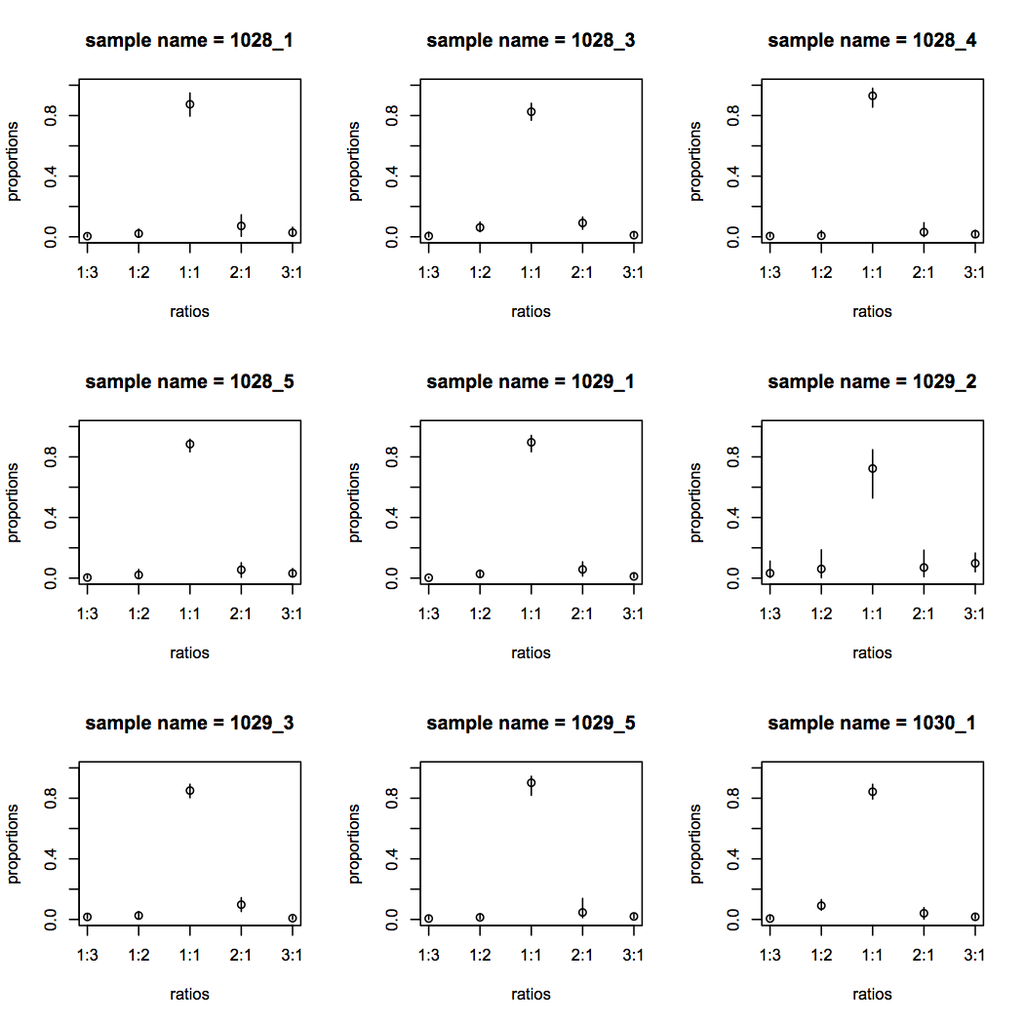

Continue r code: estploidy  
NOTE: You probably wouldn’t run estploidy unless you have some samples of known ploidy (a training set)  
Also, not sure how well this would work for an allopolyploid. It’s perfect for autotetraploids because all loci behave as the same ploidy.

Here, I’ll show you how you’d continue….(though the data I used for this example have NO training set and the ones that are polyploid are a result of allopolyplidy)

```r
# estploidy
#Use principal component analysis (PCA) and discriminant analysis (DA) to assign individuals to different cytotype groups based on GBS data. This function can be run with or without a training set of individuals with known cytotypes.

# Usage:
#estploidy(alphas = NA, het = NA, depth = NA, train = FALSE, pl = NA, set = NA, nclasses = 2, ids = NA, pcs = 1:2)
#Arguments:
'''
alphas a list generated by the estprops function that contains posterior estimates of
allelic proportions.
het a numeric vector with the observed heterozygosity for each individual, that is
the proportion of SNPs at which the individual was heterozygous.
depth a numeric vector with the mean number of reads per SNP for each individual
(all SNPs or just heterozygous SNPs).
train a boolean specifying whether or not a training set with known ploidy should be
used.
pl a vector of known ploidies with one entry per individual (use ‘NA’ for individuals
with unknown ploidy); only used if train == TRUE.
set indixes for the training set; only used if train == TRUE.
nclasses the number of cyotypes expected.
ids names or other IDs for individuals.
pcs a vector giving the PC to use for DA.
'''
## CALCULATE OBSERVED HETEROZYGOSITY
# get the proportion of loci that are heterozygous from each sample (i.e. sample heterozygosity)
# for each sample (2 refers to column), this counts the number of NAs (is.na(cov1)==FALSE), and then divids by the total number of SNPs (mean)
# Note: Obviously, whether you do this on cov1 or cov2, you'd get the same answer.
H<-apply(is.na(cov1)==FALSE,2,mean) # length(H) = 181

## CALCULATE DEPTH OF COVERAGE
# Here, we remove the NAs (na.rm=TRUE), and add the a and b allele counts per each SNP (cov1+cov2) and then take the average for each sample (2)
D<-apply(cov1+cov2,2,mean,na.rm=TRUE) # length(D) = 181

## run estploidy without using known ploidy data
pl<-estploidy(alphas=propOut,het=H,depth=D,train=FALSE,pl=NA,set=NA,nclasses=2,ids=ids,pcs=1:2)
```